# Open Court Analytics — Interactive Dashboard & Brief

Maryland District Court Eviction Warrant Timelines (Apr–Sep 2026) & Responsible LLM Document Extraction Benchmark

[GitHub Repo](https://github.com/mhadeli/open-court-analytics) [AI Scorecard](https://github.com/mhadeli/open-court-analytics/blob/main/docs/AI_EVALUATION_SCORECARD.md) [Limitations Memo](https://github.com/mhadeli/open-court-analytics/blob/main/docs/LIMITATIONS_MEMO.md)

Valid Warrant Petitions

51,948

All 24 MD jurisdictions (100k raw events)

Censor-Adjusted Median

65.0 days

vs. 46.0d naive closed median (+41% bias)

Overall Clearance Rate

47.0%

24,406 closed | 27,542 open (53.0%)

Executed Eviction Rate

8.7%

4,526 warrants returned evicted

LLM Unsupported Quotes

0.0%

60 held-out MD court orders verified

## Three Headline Operational Findings

1. **Ignoring open cases understates processing time by 41%.** Naive closed-case medians report **46.0 days**, whereas Kaplan–Meier survival analysis right-censoring the **27,542 still-open petitions (53.0%)** yields a true median of **65.0 days** (+19 days).
2. **Cross-county disparities reflect both operational pace and local clerk logging practices.** Closed petitions resolve fastest in rural jurisdictions (Allegany 12d, Cecil 15d) and slowest in high-volume urban dockets (Anne Arundel 55d, Baltimore City 54d, Prince George's 53d). Crucially, Baltimore City records almost no `Cancelled` (61) or `Expired` (0) warrant returns in this feed—making raw clearance-rate comparisons misleading without schema audits.
3. **Hybrid rule + LLM extraction beats LLM-only deployment.** On 60 held-out Maryland appellate orders, deterministic regex matched or beat the LLM on structured docket IDs (`0.950 F1`, 0.15 ms, $0) and standard decretals (`1.000 F1`), while `gemini-3.8-flash` delivered a **+24.5 Macro-F1 lift** on nuanced remand detection (`0.983` vs. `0.738`) with **0.0% unsupported citations**.

### What This Data Can and Cannot Support

- **Can support:** Quantifying survivorship bias in court time standards, diagnosing cross-county operational bottlenecks and clerk logging inconsistencies, and selecting field-level rule vs. LLM extraction policies before deployment.
- **Cannot support:** Causal claims about judicial bias, landlord intent, or tenant outcomes. Public records omit tenant counsel status, rent arrears, informal payment agreements, and Baltimore City warrant cancellations.

## Kaplan–Meier Time-to-Disposition & Survivorship Bias

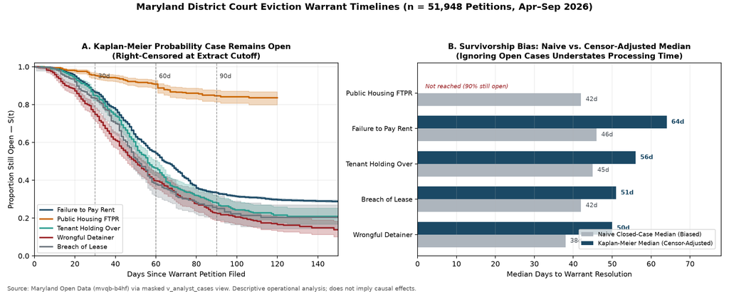

## Survival Benchmarks by Cohort

Group Type:

[output not shown]

## Fixed-Effects Survival & Clustered Logistic Regression Estimates (95% CIs)

Model:

[output not shown]

## Maryland 24-Jurisdiction Choropleth Map (Small-Cell <10 Suppressed)

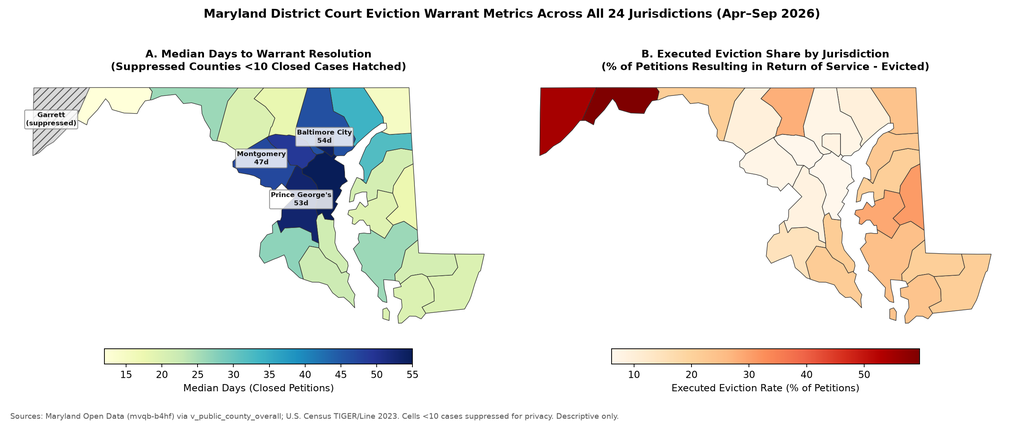

## Interactive County & Region Explorer

Region: Search County:

Filings Dispositions Executed Evictions

### Jurisdiction Breakdown (Click Column Headers to Sort)

[output not shown]

Rules (Regex)

0.871 F1

89.7% acc | 0.15 ms | $0.00 / 1k

Classical NLP (spaCy/TF-IDF)

0.499 F1

68.9% acc | 80.9 ms | $0.00 / 1k

Gemini 3.8 Flash (Schema)

0.862 F1

92.2% acc | 6,968 ms | $0.39 / 1k

Remand Detection Lift

+24.5 F1

LLM 0.983 vs. Rules 0.738

## Pre-Deployment AI Readiness Scorecard (Non-Technical Decision Matrix)

| Status | Extraction Field | Recommended Engine | Operational Guidance |
| --- | --- | --- | --- |
| GREEN | `case_number` | Deterministic Regex | 0.950 F1 at 0.15 ms and $0.00. Add multi-docket regex to close the remaining 3% gap without LLM latency. |
| GREEN | `disposition_outcome` | Deterministic Rules + LLM fallback | 1.000 F1 on standardized appellate decretal lines. Route unstructured trial-court orders to Yellow review. |
| YELLOW | `remand_or_procedural_stay_flag` | LLM (`UNKNOWN` + Quote Check) | 0.983 F1 (2.3% OCR drop vs. 12.5% for rules). Ideal for human-in-the-loop triage with verbatim quote highlighting. |
| YELLOW | `case_category` | LLM + Human Tie-Break Rules | 0.744 F1 (76.7% acc). Real disputes straddle civil/property boundaries; suitable for draft tagging, not binding routing. |
| YELLOW | `self_represented_flag` | Structured Counsel Parser + Clerk Check | LLMs can misread solo attorneys without firm names as *pro se*; cross-check against CMS attorney/bar tables. |
| RED | `monetary_judgment_amount` | Do Not Automate Binding Entry | Rules dropped unit multipliers ($147M → $147); LLM abstained on 39% of real amounts. Assistive highlight only. |

## Per-Field Extraction Benchmark (n = 60 Held-Out Maryland Orders)

Method:

[output not shown]

## Phase 1 Warehouse QA & Privacy Audit

[output not shown]

## Local Clerk Logging Audit (Major Jurisdictions)

Even within a single statewide open-data feed, local clerks do not log non-eviction return-of-service events uniformly.

| Jurisdiction | Evicted | Cancelled | Expired | Pending |
| --- | --- | --- | --- | --- |
| **Baltimore County** | 1,119 | 6,717 | 2,281 | 5,189 |
| **Montgomery County** | 235 | 1,884 | 165 | 1,100 |
| **Prince George's County** | 696 | 3,654 | 0 | 3,890 |
| **Baltimore City** | 1,197 | 61 | 0 | 13,487 |

### Privacy Controls Enforced in SQL

- Downstream scripts query only `v_analyst_cases` (salted SHA-256 `case_id_hash`, raw city & 5-digit ZIP removed, coarsened to 3-digit `tenant_zip3`).
- Public county/monthly exports enforce strict **small-cell suppression (< 10 cases)**—suppressing 38 county-category cells and Garrett County's closed-case median (`n_closed = 7`).
- Automated assertions in `build_warehouse.py` fail the build if any PII column or unsuppressed cell leaks.